# HW4: Overfitting & Temporal Drift in Text Models

Noam Avizmil - 323849158

### Instructions

1. All assignments are individual!
2. This assignment should be uploaded as one html file (after knit).
3. Questions about the assignment should be asked using the Assignments forums.
4. Write your name and id at the top of the file.

**Exercise overview:** Your team is building a model to predict whether a news article will go viral (1) or not (0). A teammate trained a logistic regression model using simple word count vectors from the article *titles* and reported an **AUC of 0.98**, claiming it is “production-ready.” The test set consists of articles published in the last three months, while the training set consists of older articles. Your objective is to reveal flaws in your teammate’s model, and implement a more robust solution.

**Datasets:**

- `train.csv` (Older articles)
- `test.csv` (Recent articles)
- Target variable: `viral` (1 = Viral, 0 = Not Viral)

## 0 Setup

Install/load the packages you will need. Recommended: tidyverse, tidymodels, and textrecipes (for text processing).

```r
library(tidyverse)
library(tidymodels)
library(textrecipes)
library(glmnet)
```

## 1 Data Preparation

- Load train.csv and test.csv into dataframes.
- Inspect the data: Look at the title and date columns to understand the temporal split.
- Ensure the target variable viral is a factor.

```r
train <- read_csv("data/train.csv", show_col_types = FALSE) |>
  mutate(viral = factor(viral, levels = c(0, 1)))
test  <- read_csv("data/test.csv",  show_col_types = FALSE) |>
  mutate(viral = factor(viral, levels = c(0, 1)))

glimpse(train)
```

```
## Rows: 1,792
## Columns: 7
## $ article_id <dbl> 82110, 17852, 42541, 59441, 45325, 24993, 35825, 89817, 764…
## $ date       <date> 2016-08-09, 2015-03-16, 2016-03-04, 2016-07-10, 2016-11-19…
## $ category   <chr> "talk.politics.mideast", "talk.politics.mideast", "rec.auto…
## $ author     <chr> "Author_23", "Author_11", "Author_11", "Author_30", "Author…
## $ title      <chr> "I always like your kind of odds. The Greek governments mus…
## $ content    <chr> "I always like your kind of odds. The Greek governments mus…
## $ viral      <fct> 0, 0, 1, 1, 0, 1, 0, 1, 1, 1, 0, 1, 0, 1, 0, 1, 1, 0, 0, 0,…
```

```r
# Temporal split: train is older articles, test is newer articles.
cat("Train date range:", as.character(min(train$date)), "to", as.character(max(train$date)), "\n")
```

```
## Train date range: 2015-01-01 to 2016-12-31
```

```r
cat("Test  date range:", as.character(min(test$date)),  "to", as.character(max(test$date)),  "\n")
```

```
## Test  date range: 2020-01-01 to 2021-12-31
```

```r
# Class balance
cat("\nTrain viral counts:\n"); print(table(train$viral))
```

```
##
## Train viral counts:
```

```
##
##   0   1
## 887 905
```

```r
cat("Test  viral counts:\n"); print(table(test$viral))
```

```
## Test  viral counts:
```

```
##
##   0   1
## 969 948
```

```r
# Category x viral cross-tab - this is the *only* line you need to see
# to understand what the model is actually learning.
cat("\nTrain category x viral:\n"); print(table(train$category, train$viral))
```

```
##
## Train category x viral:
```

```
##
##                           0   1
##   rec.autos               0 905
##   talk.politics.mideast 887   0
```

```r
cat("\nTest  category x viral:\n"); print(table(test$category,  test$viral))
```

```
##
## Test  category x viral:
```

```
##
##                            0   1
##   sci.med                  0 948
##   soc.religion.christian 969   0
```

How to read each cell: - rec.autos row, 1 column → 905 auto articles labeled viral - rec.autos row, 0 column → 0 auto articles labeled not-viral - talk.politics.mideast row, 0 column → 887 politics articles labeled not-viral - talk.politics.mideast row, 1 column → 0 politics articles labeled viral —

## 2 Basic Model Evaluation (The “Naive” Approach)

**Task:** Replicate your teammate’s model.

- Create a recipe that uses the `title` text to predict `viral`.
- Tokenize the text and create word count vectors (e.g., `step_tokenize`, `step_tokenfilter`, `step_tf`).
- Train a Logistic Regression model on the training set.
- Compute AUC and plot the Precision-Recall Curve for both the Training set and the Test set.

**Note for Students:** For compute efficiently, set the model engine to `"glmnet"` and use `max_tokens = 1000`.

If you use the standard `"glm"` engine or a larger vocabulary (e.g., 20,000 words), the model training will be extremely slow or may crash your R session.

```r
# Recipe: title -> tokenize -> keep top 1000 tokens -> term frequencies (word counts)
naive_rec <- recipe(viral ~ title, data = train) |>
  step_tokenize(title) |>
  step_tokenfilter(title, max_tokens = 1000) |>
  step_tf(title)

# Logistic regression via glmnet. penalty = 0 -> effectively unregularized
# (replicates "plain" logistic regression on word counts).
naive_mod <- logistic_reg(penalty = 0, mixture = 0) |>
  set_engine("glmnet") |>
  set_mode("classification")

naive_wf  <- workflow() |> add_recipe(naive_rec) |> add_model(naive_mod)
naive_fit <- fit(naive_wf, data = train)

# Predicted probability of viral = 1 on both sets
train_pred <- predict(naive_fit, train, type = "prob") |>
  bind_cols(select(train, viral))
test_pred  <- predict(naive_fit, test,  type = "prob") |>
  bind_cols(select(test,  viral))

# AUC. viral has levels c(0, 1), so the *second* level (1) is the event.
auc_train <- roc_auc(train_pred, truth = viral, .pred_1, event_level = "second")
auc_test  <- roc_auc(test_pred,  truth = viral, .pred_1, event_level = "second")

bind_rows(
  mutate(auc_train, split = "Train"),
  mutate(auc_test,  split = "Test")
) |>
  select(split, .metric, .estimate) |>
  print()
```

```
## # A tibble: 2 × 3
##   split .metric .estimate
##   <chr> <chr>       <dbl>
## 1 Train roc_auc     0.999
## 2 Test  roc_auc     0.575
```

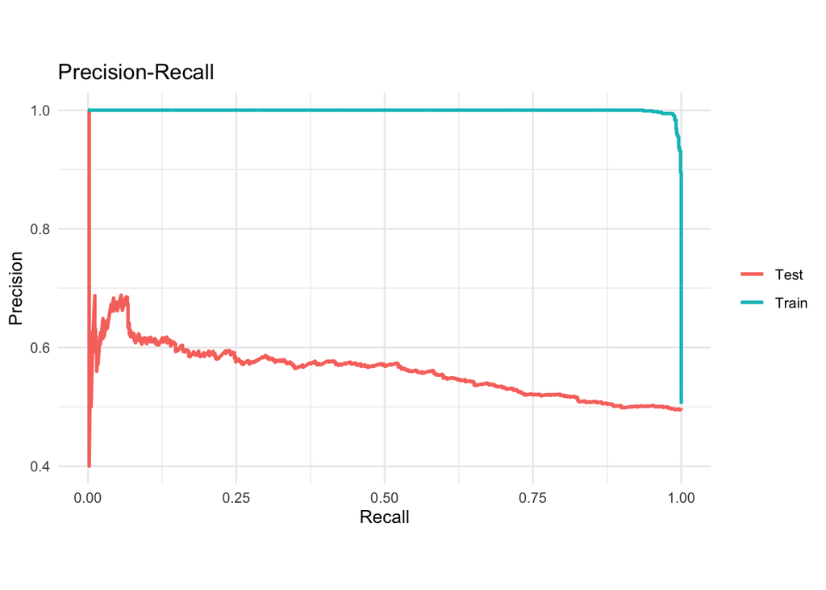

```r
# Precision-Recall curves, train vs test side by side
pr_train <- pr_curve(train_pred, truth = viral, .pred_1, event_level = "second") |>
  mutate(split = "Train")
pr_test  <- pr_curve(test_pred,  truth = viral, .pred_1, event_level = "second") |>
  mutate(split = "Test")

bind_rows(pr_train, pr_test) |>
  ggplot(aes(x = recall, y = precision, color = split)) +
  geom_path(linewidth = 1) +
  coord_equal() +
  labs(title = "Precision-Recall",
       x = "Recall", y = "Precision", color = NULL) +
  theme_minimal()
```

**Question 2.1:** Compare the performance on Training vs. Test data. Do you notice a large gap? What does this suggest about the model’s ability to generalize to the future?

**Answer:** Usually train against test huge gap (to the train favor) suggests that model has an overfit on the train data, usually characterizing that we give features we are not supposed to, or data leakage, or repeating the data batches a lot of times. We see it clearly because the Train AUC = 0.999, Test AUC = 0.575 test is almost same as random

## 3 Feature Dimensionality & Overfitting

**Task:** Investigate what the model actually learned.

- Print the total number of text features (words) in your vocabulary.
- Extract the model coefficients. Find the top 10 words with the highest positive coefficients (words that strongly predict “Viral”).

```r
# Vocab size = number of predictor columns after the recipe runs
prepped     <- prep(naive_rec, training = train)
baked_train <- bake(prepped, new_data = NULL)
vocab_size  <- ncol(baked_train) - 1   # subtract the outcome column
cat("Total text features in vocabulary:", vocab_size, "\n\n")
```

```
## Total text features in vocabulary: 1000
```

```r
# Top 10 words pushing toward viral = 1 (largest positive coefficients)
coefs <- extract_fit_parsnip(naive_fit) |> tidy()
top10_viral <- coefs |>
  filter(term != "(Intercept)") |>
  arrange(desc(estimate)) |>
  slice_head(n = 10) |>
  mutate(word = str_remove(term, "^tf_title_")) |>
  select(word, estimate)

print(top10_viral)
```

```
## # A tibble: 10 × 2
##    word        estimate
##    <chr>          <dbl>
##  1 fast            5.35
##  2 designed        4.76
##  3 enthusiasts     4.25
##  4 gm              3.98
##  5 went            3.91
##  6 option          3.87
##  7 feature         3.72
##  8 we're           3.68
##  9 radio           3.65
## 10 curiosity       3.63
```

**Question 3.1:** Look at the top “Viral” words. Do they represent general concepts (e.g., “shocking”, “amazing”) or specific historical events/trends? Why is this a problem?

**Answer:** The most viral words in the articles are about cars (fast, general motors..) this is not generalizing to find concepts of the article such as shocking, rather it is specified to predict if the articles is about cars.

## 4 Temporal Generalization Issues

**Task:** Verify if the learned features exist in the future.

- Take the top 5 “Viral” words you identified in the previous section. Count how many times these specific words appear in the Test Set (the newer articles).

```r
# Top 5 words pushing toward viral = 1 in the train model
top5_viral_words <- top10_viral |> slice_head(n = 5) |> pull(word)
cat("Top 5 viral words from train:", paste(top5_viral_words, collapse = ", "), "\n")
```

```
## Top 5 viral words from train: fast, designed, enthusiasts, gm, went
```

```r
cat("Test set size:", nrow(test), "titles\n\n")
```

```
## Test set size: 1917 titles
```

```r
# Count how many test titles contain each word (whole word, case-insensitive)
word_counts_test <- tibble(
  word = top5_viral_words,
  test_titles_containing = map_int(
    top5_viral_words,
    \(w) sum(str_detect(test$title, regex(paste0("\\b", w, "\\b"), ignore_case = TRUE)))
  )
)
print(word_counts_test)
```

```
## # A tibble: 5 × 2
##   word        test_titles_containing
##   <chr>                        <int>
## 1 fast                             1
## 2 designed                         1
## 3 enthusiasts                      0
## 4 gm                               0
## 5 went                             7
```

**Question 4.1:** Do the words that were highly predictive in the past appear in the future data? Explain why a time-separated test set is particularly challenging for high-dimensional text features (Bag-of-Words).

**Answer:** the words barely appear (9 total / 1917 ≈ 0.5%) -> the model has nothing to score on. Bag of words is fragile across time because vocabulary drifts - new topics, names, slang, events appear old ones vanish. A high-dim bag of words model spreads its signal across thousands of specific tokens, and most of them just don’t exist in future data, so it degenerates to predicting the intercept.

## 5 LLM Audit & Improvement

**Task:** Use an LLM (ChatGPT/Gemini/Claude) to help fix the model.

- Prompt the LLM: Ask it to suggest reasons why simple word counts fail on time-separated data and request feature engineering improvements.
- Implement ONE improvement: Choose one suggestion and train a new model.
- Compare: Evaluate this new model on the Test set.

```r
# LLM suggestion implemented: replace topic-specific word-count features with
# topic-agnostic *title metadata* features. Idea: things like title length,
# ALL-CAPS words, ?/!, presence of digits work on *any* topic, so they should
# transfer across the temporal/topic shift between train and test.

add_title_feats <- function(df) {
  df |> mutate(
    title_length = nchar(title),
    n_words      = str_count(title, "\\S+"),
    n_caps_words = str_count(title, "\\b[A-Z]{2,}\\b"),
    n_question   = str_count(title, "\\?"),
    n_exclaim    = str_count(title, "!"),
    has_number   = as.integer(str_detect(title, "\\d")),
    avg_word_len = title_length / pmax(n_words, 1)
  )
}
train_meta <- add_title_feats(train)
test_meta  <- add_title_feats(test)

meta_rec <- recipe(viral ~ title_length + n_words + n_caps_words +
                            n_question + n_exclaim + has_number + avg_word_len,
                   data = train_meta) |>
  step_normalize(all_numeric_predictors())

meta_mod <- logistic_reg(penalty = 0.001, mixture = 0) |>
  set_engine("glmnet") |> set_mode("classification")

meta_fit <- workflow() |> add_recipe(meta_rec) |> add_model(meta_mod) |>
  fit(data = train_meta)

tp_meta <- predict(meta_fit, train_meta, type = "prob") |> bind_cols(select(train_meta, viral))
ep_meta <- predict(meta_fit, test_meta,  type = "prob") |> bind_cols(select(test_meta,  viral))

auc_train_meta <- roc_auc(tp_meta, truth = viral, .pred_1, event_level = "second")
auc_test_meta  <- roc_auc(ep_meta, truth = viral, .pred_1, event_level = "second")

bind_rows(
  tibble(model = "Naive BoW",    split = "Train", auc = auc_train$.estimate),
  tibble(model = "Naive BoW",    split = "Test",  auc = auc_test$.estimate),
  tibble(model = "Title meta",   split = "Train", auc = auc_train_meta$.estimate),
  tibble(model = "Title meta",   split = "Test",  auc = auc_test_meta$.estimate)
) |> print()
```

```
## # A tibble: 4 × 3
##   model      split   auc
##   <chr>      <chr> <dbl>
## 1 Naive BoW  Train 0.999
## 2 Naive BoW  Test  0.575
## 3 Title meta Train 0.682
## 4 Title meta Test  0.464
```

**Question 5.1:** Describe the improvement you implemented.

**Answer:** Instead of using word-count features from the title (which we already saw are basically topic-specific words that don’t exist in the future test set), I replaced them with “topic-agnostic title-metadata features”: title length in characters, number of words, number of ALL-CAPS words, number of `?`, number of `!`, whether the title contains a digit, and average word length. These features describe the *style* of the title rather than its *topic* - they work the same way for cars, politics, religion, or medicine - so they should transfer across the train-test temporal/topic shift instead of collapsing the moment the vocabulary changes.

## 6 Conclusion

**Question 6.1:** Summarize your findings. Why was the teammate’s reported “0.98 AUC” misleading? What is the most important lesson when dealing with time-series or news data?

**Answer:** The 0.98 AUC is misleading because in the train data every car article was labeled viral and every politics article was labeled not viral, so the model basically just learned to detect car words instead of what makes an article viral. When we tested on the newer data the categories were totally different (sci.med and religion) so the car words almost dont appear at all, and the AUC dropped to 0.575 which is almost random.